# OMICsPCA: An R package for quantitative integration and analysis of multiple omics assays from heterogeneous samples

### 3.8.1 1D plots

Here is a discriminatory factor:

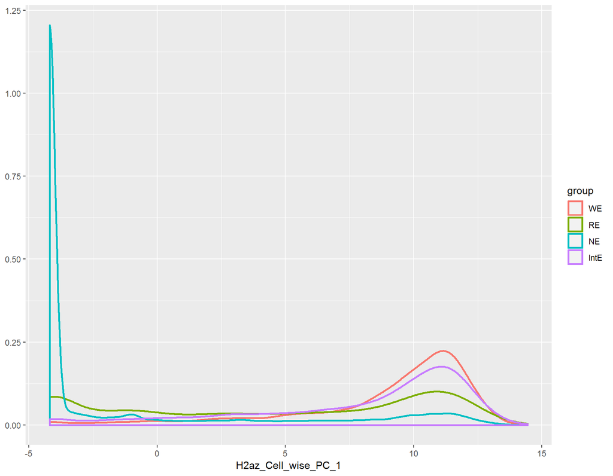

```r
densityplot <- plot_density(name = "OMICsdata", Assay = "H2az_Cell_wise",
PC = 1, groups = c("WE","RE","NE","IntE"),
adjust = 1)
```

```r
class(densityplot)
# [1] "gg"     "ggplot"
```

Density plots can be modified using other graphical functions like xlim(), theme() etc.

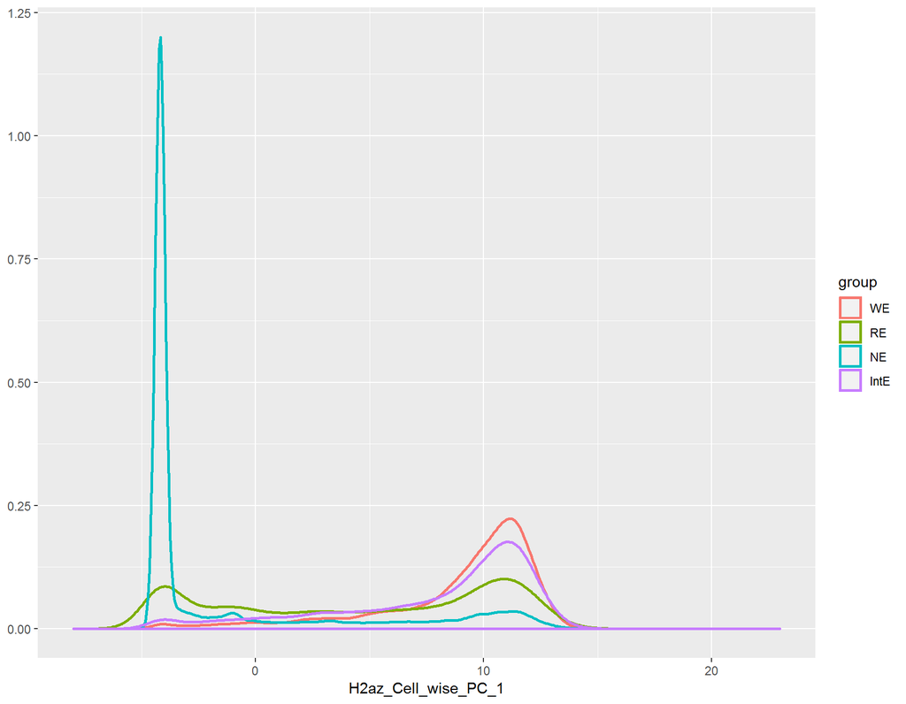

```r
library(ggplot2)
# Warning: package 'ggplot2' was built under R version 3.5.1
library(graphics)

densityplot <- densityplot+xlim(as.numeric(c("-8", "23")))
densityplot
```

and here is a non-discriminatory factor:

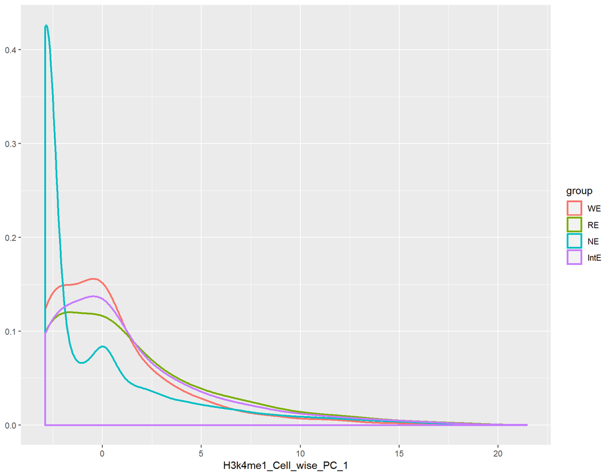

```r
densityplot <- plot_density(name = "OMICsdata", Assay = "H3k4me1_Cell_wise",
PC = 1, groups = c("WE" ,"RE" ,"NE" ,"IntE"), adjust = 2)
```

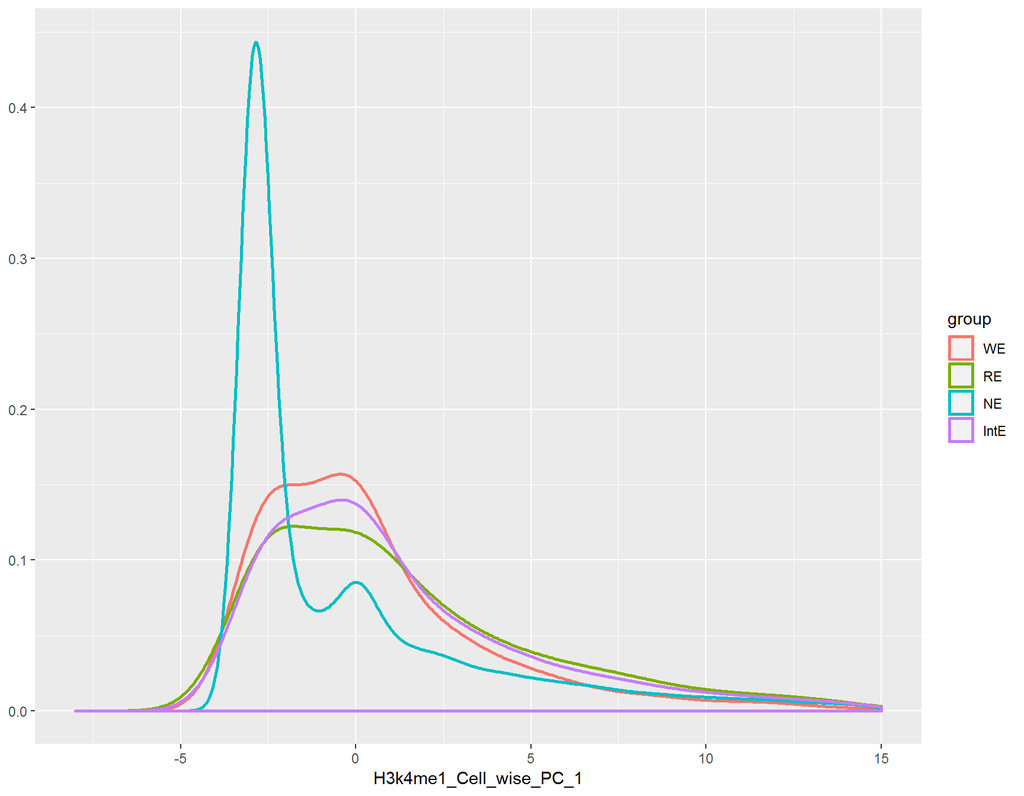

```r
densityplot <- densityplot+xlim(as.numeric(c("-8", "15")))

print(densityplot)
# Warning: Removed 1479 rows containing non-finite values (stat_density).
```

### 3.8.2 3D plots

OMICsPCA also has a function to visualize the density the scores on 2 principal components together in 3D

#### 3.8.2.1 static = FALSE

If `static` is set to “FALSE” the function opens the interactive 3D density plot in a new window.

```r
plot_density_3D(name = "OMICsdata", Assay = "H2az_Cell_wise", group = "WE",
PC1 = 1,PC2 = 2, grid_size = 100, static = FALSE)
```

#### 3.8.2.2 static = TRUE

If `static` is set to “TRUE”, some additional graphical parameters may be supplied

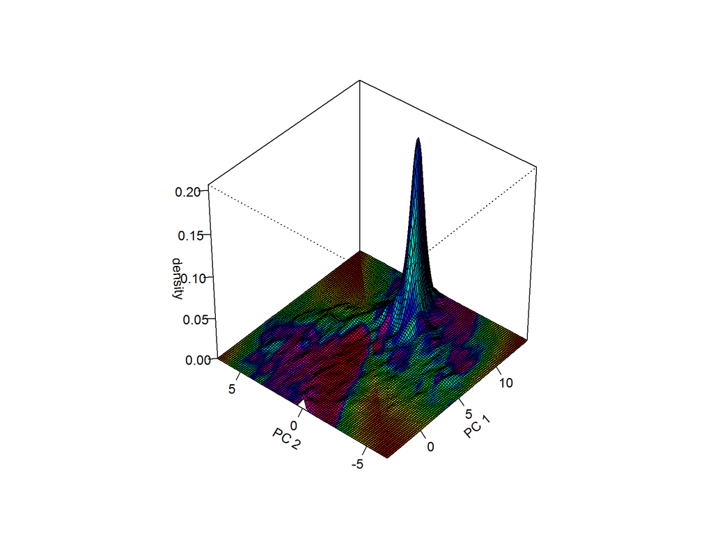

```r
plot_density_3D(name = "OMICsdata", Assay = "H2az_Cell_wise", group = "WE",
PC1 = 1,PC2 = 2, grid_size = 100, static = TRUE, theta = -50,
phi = 40, box = TRUE, shade = 0.1, ticktype = "detailed", d = 10)
# Warning in persp.default(x = bivn.kde, col = col1, xlab = labx, ylab =
# laby, : "grid_size" is not a graphical parameter
```

**NOTE :** 2D density is calculated using the **kde2d** function from package **MASS** which use kernel density estimation (KDE) to calculate the density of 2D data. Now, if the variance on either or both of the PCs are 0, the KDE can’t be calculated. Here is an example,

```r
plot_density_3D(name = "OMICsdata", Assay = "H2az_Cell_wise", group = "NE",
PC1 = 1,PC2 = 2, grid_size = 100, static = TRUE, theta = -50,
phi = 40, box = TRUE, shade = 0.1, ticktype = "detailed", d = 10)
```

will show this error:

```
Error in kde2d(scores[, 1], scores[, 2], n = gridsize) :
bandwidths must be strictly positive
```

## 3.9 Integration of multiple assays

Once the discriminatory Assays between the groups are identified by previous analyses, we may integrate all such assays together.

```r
Assays = c("H2az_Cell_wise", "H3k9ac_Cell_wise")
```

In this process it is possible to observe that some variables (Cell lines) are not similar to others and thus can be excluded :

```r
exclude <- list(0,c(1,9))
```

The length of the list “exclude” should be equal to the Number of assays (i.e. length of “Assays”“). If no columns are selected for exclusion, a”0" should be placed in the “exclude” list. In the above example, we are excluding none of the columns from “H2az_Cell_wise” and column 1 and 9 from “H3k9ac_Cell_wise”

The integration of multiple assays is handled by **integrateAssays** function in OMICsPCA. It works in 2 modes:

1. runs PCA on selected groups created by **create_group()** function
2. runs PCA on all individuals (e.g. annotations: gene, TSS etc.)

The type of merging the assays should be entered by the argument `mergetype`

**integrateAssays()** returns a list containing the start and end column of each Assay in the integrated Assay

```r
start_end <- integrateAssays(Assays = c("H2az_Cell_wise",
"H3k9ac_Cell_wise"), name = "OMICsdata", mergetype = 2,
exclude = exclude, graph = FALSE)
```

if `mergetype` is set to 1, then **integrateAssays** asks for the name of groups to be integrated.

```
Enter a vector of strings containing group names:
```

Here is an example of the allowed input

```
Enter a vector of strings containing group names: c("WE","RE")
```

## 3.10 Analysis of integrated data

All the analyses on variables and individuals of integrated Assays are designed to be done by the functions **analyse_integrated_variables()** and **analyse_integrated_individuals()**. These functions work similarly as **analyse_variables()** and **analyse_individuals()** described in section **3.6** and **3.7**. The only difference between the analyses in section **3.6** and **3.7** is that in those sections multiple cell lines from a single type of assay were integrated. Whereas, the analyses described in this section will be on multiple assays or modalities.

### 3.10.1 Analyses of variables

The extra argument needs to be supplied in **analyse_integrated_variables()** is `start_end` which is the returned value by **integrateAssays()**.

The `Assay` argument works a little bit differently here. it takes the number corresponding to the order of assays used in the `Assays` argument of **integrateAssays()**. For example, in the above example `Assays` = c(“H2az_Cell_wise”, “H3k9ac_Cell_wise”). So here `Assay` = 1 indicates to “H2az_Cell_wise” and 2 = “H3k9ac_cell_wise”

The default argument set to `Assay` is “all”, which show analyses on full integrated assays. Here are some examples:

#### 3.10.1.1 choice = 1

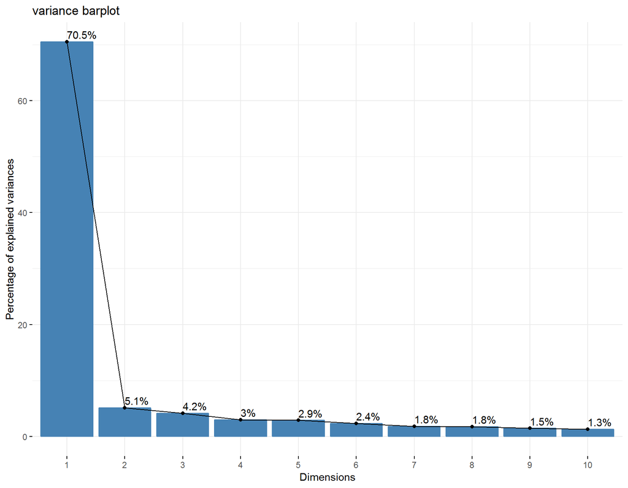

```
#        eigenvalue variance.percent cumulative.variance.percent
# Dim.1  11.2785626       70.4910162                    70.49102
# Dim.2   0.8238060        5.1487873                    75.63980
# Dim.3   0.6662760        4.1642251                    79.80403
# Dim.4   0.4757188        2.9732428                    82.77727
# Dim.5   0.4634762        2.8967263                    85.67400
# Dim.6   0.3769878        2.3561736                    88.03017
# Dim.7   0.2944345        1.8402155                    89.87039
# Dim.8   0.2854485        1.7840531                    91.65444
# Dim.9   0.2348603        1.4678766                    93.12232
# Dim.10  0.2063641        1.2897757                    94.41209
# Dim.11  0.2040527        1.2753297                    95.68742
# Dim.12  0.1681539        1.0509619                    96.73838
# Dim.13  0.1558582        0.9741139                    97.71250
# Dim.14  0.1534076        0.9587973                    98.67129
# Dim.15  0.1106141        0.6913379                    99.36263
# Dim.16  0.1019787        0.6373671                   100.00000
```

```r
analyse_integrated_variables(start_end = start_end, name = "OMICsdata",
choice = 1, title = "variance barplot", addlabels = TRUE)
```

A large part of the total variance in the 2 assays (H2az_Cell_wise and H3k9ac_Cell_wise) are captured by PC1 alone. This indicates that these two Histone modifications are very similar and this is followed by most of the cell lines. Remember the `mergetype` was set to 2 in **integrateAssays()**, which uses all the groups **(“WE”, “RE”, “NE”,“IntE”)** . This analysis may overshadow the true structure of data due to a strong influence of “NE”, coming from their large number. So redoing the analysis on smaller groups (use `mergetype` = 1 in integrateAssays()) may be useful in this context.

#### 3.10.1.2 choice = 2

```r
analyse_integrated_variables(start_end = start_end, Assay = 1,
name = "OMICsdata", choice = 2 ,
title = "Loadings of cell lines on PC1 and PC2",
var_type = "contrib")
```

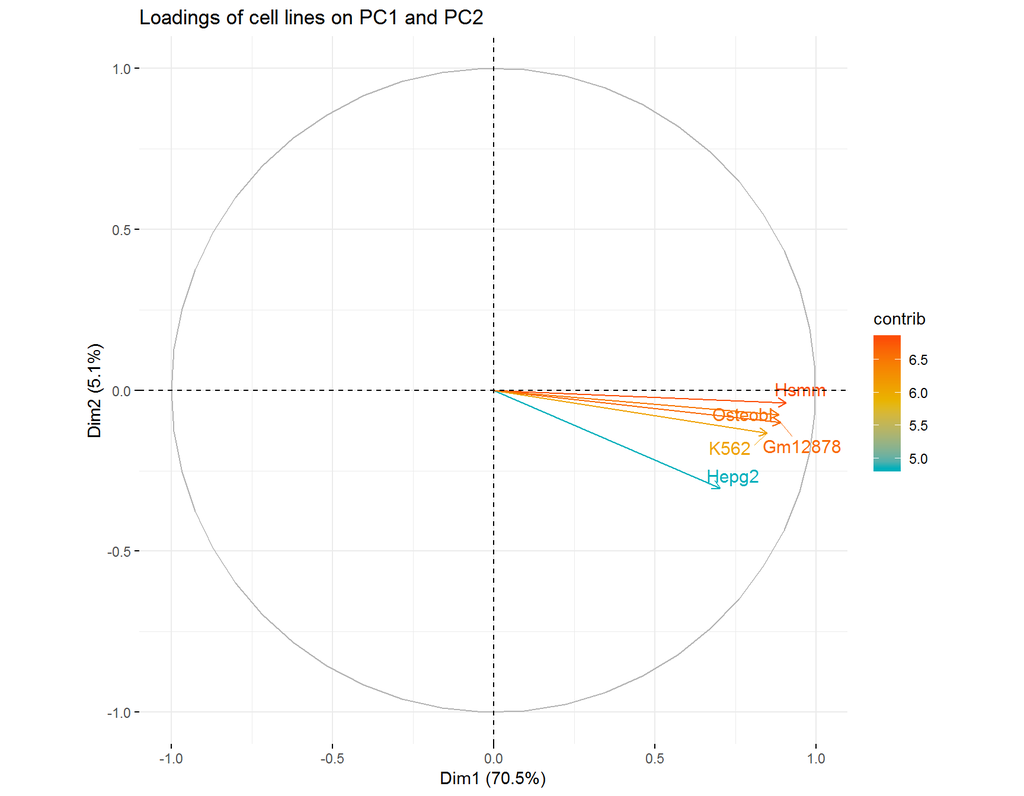

```
#            Dim.1      Dim.2     Dim.3       Dim.4      Dim.5      Dim.6
# Gm12878 7.019011  1.2022488  4.363976 0.291303442  1.9215282  4.6885934
# Hepg2   4.393136 11.1677691 39.321690 0.000174136  1.5736144 23.4659659
# Hsmm    7.301528  0.1798474  2.212726 0.368788009  6.7670216  2.1489352
# K562    6.377948  2.1539977  5.903030 0.341823532  0.4280165  8.4930567
# Osteobl 6.939920  0.6948640  4.231786 0.553465147 11.1108419  0.2422759
#              Dim.7        Dim.8     Dim.9       Dim.10   Dim.11
# Gm12878  3.7985466  0.063925338 0.1367839 3.538108e-03 8.438047
# Hepg2    7.1821780  8.436740487 1.7452647 6.803952e-04 2.551384
# Hsmm     1.7167732  6.699253439 8.4147624 2.608879e+00 1.240043
# K562    38.2841992  0.001052331 7.6878611 1.426352e+01 2.104304
# Osteobl  0.5608388 10.062792723 8.5792964 7.950644e+00 1.982927
#               Dim.12      Dim.13      Dim.14       Dim.15      Dim.16
# Gm12878 53.461394565 14.24693821 0.002776747 2.371410e-01  0.12424788
# Hepg2    0.001205519  0.11738886 0.005801164 2.622110e-03  0.03438516
# Hsmm     0.573802616  0.89098246 3.173102481 3.667644e+01 19.02711452
# K562    13.829331294  0.03768112 0.073091240 2.339767e-06  0.02108900
# Osteobl  4.834482288  7.16367507 1.044890125 1.989426e+01 14.15303909
```

We can see that almost all the cell lines are very strongly correlated with PC1. So PC1 of the integrated assays may be a representation of H2az. If we repeat this analysis for other assays, we may find out a strong correlation of multiple assays with a single PC. If this happens, we may conclude that those Assays are similar to one another. However, they may differ in various groups and cell lines under study. Therefore, the `exclude` argument in **integrateAssays** should be carefully chosen in order to exclude non-related cell types.

#### 3.10.1.3 choice = 3

```r
analyse_integrated_variables(start_end = start_end, Assay = 1,
name = "OMICsdata", choice = 3,
title = "Correlation of Cell lines with PCs of integrated Assays",
is.cor = TRUE)
```

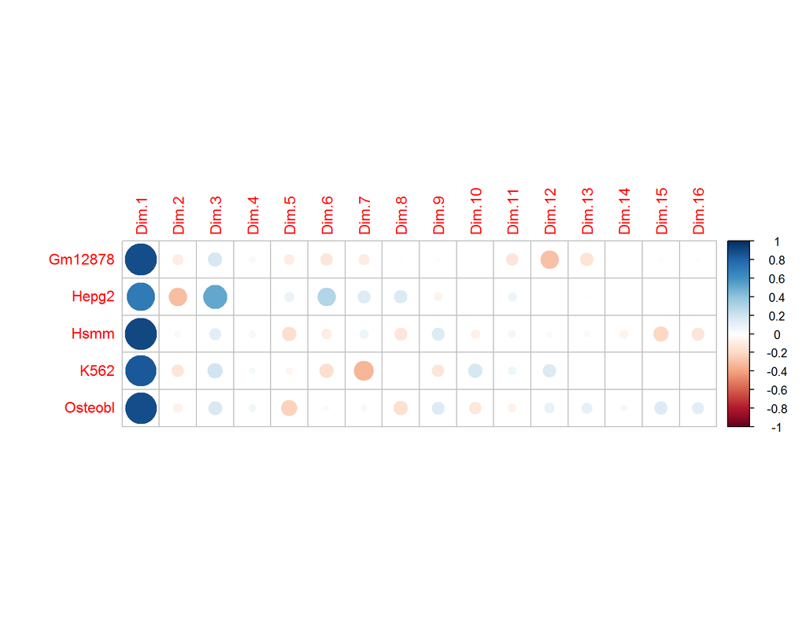

```
#             Dim.1       Dim.2     Dim.3         Dim.4       Dim.5
# Gm12878 0.8897436 -0.09951983 0.1705172  0.0372261383 -0.09437068
# Hepg2   0.7039052 -0.30331625 0.5118506 -0.0009101637  0.08540099
# Hsmm    0.9074731 -0.03849147 0.1214202  0.0418854875 -0.17709753
# K562    0.8481397 -0.13320947 0.1983191  0.0403251654 -0.04453936
# Osteobl 0.8847165 -0.07565931 0.1679148  0.0513121624 -0.22692754
#               Dim.6       Dim.7        Dim.8       Dim.9       Dim.10
# Gm12878 -0.13294895 -0.10575552 -0.013508290  0.01792347  0.002702108
# Hepg2    0.29742869  0.14541942  0.155185529 -0.06402291  0.001184944
# Hsmm    -0.09000679  0.07109692 -0.138285638  0.14058070 -0.073374309
# K562    -0.17893514 -0.33574080 -0.001733166 -0.13437161  0.171565664
# Osteobl -0.03022169  0.04063622 -0.169481827  0.14194843 -0.128090890
#              Dim.11       Dim.12       Dim.13       Dim.14        Dim.15
# Gm12878 -0.13121763 -0.299828990 -0.149013504  0.002063914  1.619603e-02
# Hepg2    0.07215379  0.001423772 -0.013526278  0.002983190  1.703063e-03
# Hsmm     0.05030250  0.031062381  0.037264855 -0.069769474 -2.014182e-01
# K562     0.06552779  0.152494462  0.007663493  0.010589027 -5.087348e-05
# Osteobl -0.06360988  0.090163024  0.105665399  0.040036741  1.483437e-01
#               Dim.16
# Gm12878  0.011256395
# Hepg2   -0.005921617
# Hsmm    -0.139296847
# K562    -0.004637489
# Osteobl  0.120137799
```

A Similar message is appearing here as observed in `choice` = 2. Hepg2 in H2az_cell_wise is relatively less correlated with PC1 and more with other PCs (Dim), indicating that it should be excluded by `exclude` argument of integrateAssays()

#### 3.10.1.4 choice = 4

```r
analyse_integrated_variables(start_end = start_end, Assay = 1,
name = "OMICsdata", choice = 4, PC = 1,
title = "Squarred loadings of Cell lines on PC1 of integrated Assays")
#             Dim.1       Dim.2      Dim.3        Dim.4       Dim.5
# Gm12878 0.7916436 0.009904198 0.02907612 1.385785e-03 0.008905826
# Hepg2   0.4954826 0.092000749 0.26199099 8.283980e-07 0.007293328
# Hsmm    0.8235074 0.001481594 0.01474286 1.754394e-03 0.031363535
# K562    0.7193409 0.017744762 0.03933047 1.626119e-03 0.001983755
# Osteobl 0.7827232 0.005724331 0.02819537 2.632938e-03 0.051496109
#                Dim.6       Dim.7        Dim.8        Dim.9       Dim.10
# Gm12878 0.0176754239 0.011184231 1.824739e-04 0.0003212509 7.301386e-06
# Hepg2   0.0884638233 0.021146808 2.408255e-02 0.0040989330 1.404092e-06
# Hsmm    0.0081012231 0.005054772 1.912292e-02 0.0197629320 5.383789e-03
# K562    0.0320177857 0.112721882 3.003863e-06 0.0180557298 2.943478e-02
# Osteobl 0.0009133506 0.001651303 2.872409e-02 0.0201493570 1.640728e-02
#              Dim.11       Dim.12       Dim.13       Dim.14       Dim.15
# Gm12878 0.017218066 8.989742e-02 2.220502e-02 4.259741e-06 2.623114e-04
# Hepg2   0.005206169 2.027127e-06 1.829602e-04 8.899424e-06 2.900422e-06
# Hsmm    0.002530342 9.648715e-04 1.388669e-03 4.867780e-03 4.056930e-02
# K562    0.004293891 2.325456e-02 5.872913e-05 1.121275e-04 2.588111e-09
# Osteobl 0.004046217 8.129371e-03 1.116518e-02 1.602941e-03 2.200585e-02
#               Dim.16
# Gm12878 1.267064e-04
# Hepg2   3.506555e-05
# Hsmm    1.940361e-02
# K562    2.150630e-05
# Osteobl 1.443309e-02
```

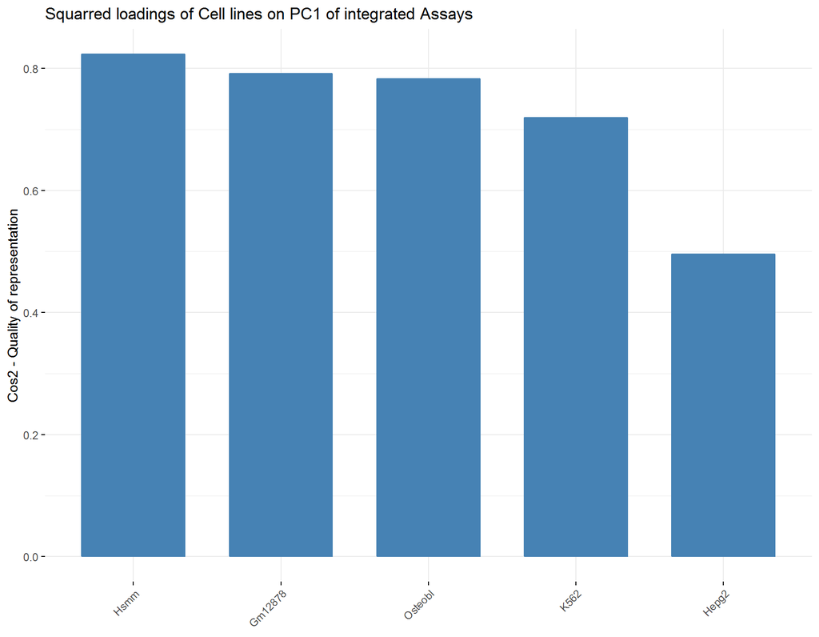

Most of the variances explained by PC1 is actually contributed by Hsmm, Gm12878,Osteobl and K562. This again indicates that Hepg2 is different from others.

#### 3.10.1.5 choice = 5

```r
analyse_integrated_variables(start_end = start_end, Assay = 1,
name = "OMICsdata", choice = 5, PC=1,
title = "Contribution of Cell lines on PC1 of integrated Assays")
```

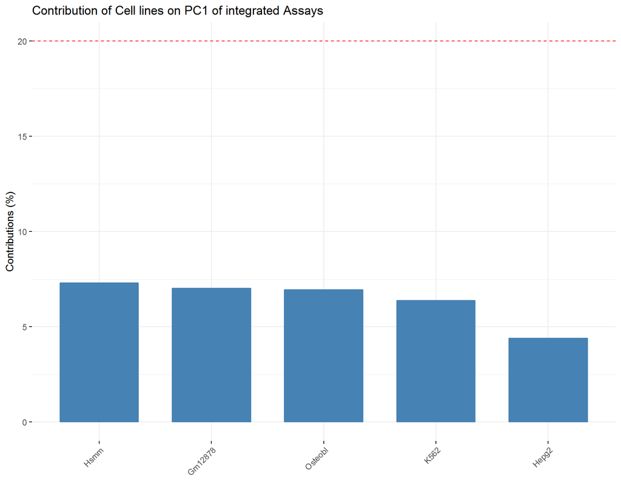

```
#            Dim.1      Dim.2     Dim.3       Dim.4      Dim.5      Dim.6
# Gm12878 7.019011  1.2022488  4.363976 0.291303442  1.9215282  4.6885934
# Hepg2   4.393136 11.1677691 39.321690 0.000174136  1.5736144 23.4659659
# Hsmm    7.301528  0.1798474  2.212726 0.368788009  6.7670216  2.1489352
# K562    6.377948  2.1539977  5.903030 0.341823532  0.4280165  8.4930567
# Osteobl 6.939920  0.6948640  4.231786 0.553465147 11.1108419  0.2422759
#              Dim.7        Dim.8     Dim.9       Dim.10   Dim.11
# Gm12878  3.7985466  0.063925338 0.1367839 3.538108e-03 8.438047
# Hepg2    7.1821780  8.436740487 1.7452647 6.803952e-04 2.551384
# Hsmm     1.7167732  6.699253439 8.4147624 2.608879e+00 1.240043
# K562    38.2841992  0.001052331 7.6878611 1.426352e+01 2.104304
# Osteobl  0.5608388 10.062792723 8.5792964 7.950644e+00 1.982927
#               Dim.12      Dim.13      Dim.14       Dim.15      Dim.16
# Gm12878 53.461394565 14.24693821 0.002776747 2.371410e-01  0.12424788
# Hepg2    0.001205519  0.11738886 0.005801164 2.622110e-03  0.03438516
# Hsmm     0.573802616  0.89098246 3.173102481 3.667644e+01 19.02711452
# K562    13.829331294  0.03768112 0.073091240 2.339767e-06  0.02108900
# Osteobl  4.834482288  7.16367507 1.044890125 1.989426e+01 14.15303909
```

A total of 16 cell lines are integrated by integrateAssays(). Therefore, the contribution of each of these 16 should be reflected on PCs, if they are of similar type. Here we see that 4 cell lines of H2az_Cell_wise contribute around 7% to PC1. This means that PC1 is not only the representation of H2az_Cell_wise, but the other assay H3k9ac_cell_wise is also represented well in PC1. However, we should redo this analysis on H3k9ac_Cell_wise to confirm.

### 3.10.2 Analysis of integrated individuals/annotations

This is the same as the analyses done using “analyse_individuals()”. The downstream analyses shown at section **3.7** are also applicable here.

#### 3.10.2.1 choice 1: 2D scatter plot

`PC` should contain 2 values and length(`col`) should match with length(`PC`)

```r
analyse_integrated_individuals(start_end = start_end,
name = "OMICsdata",
choice = 1, PC = c(1,2))
```

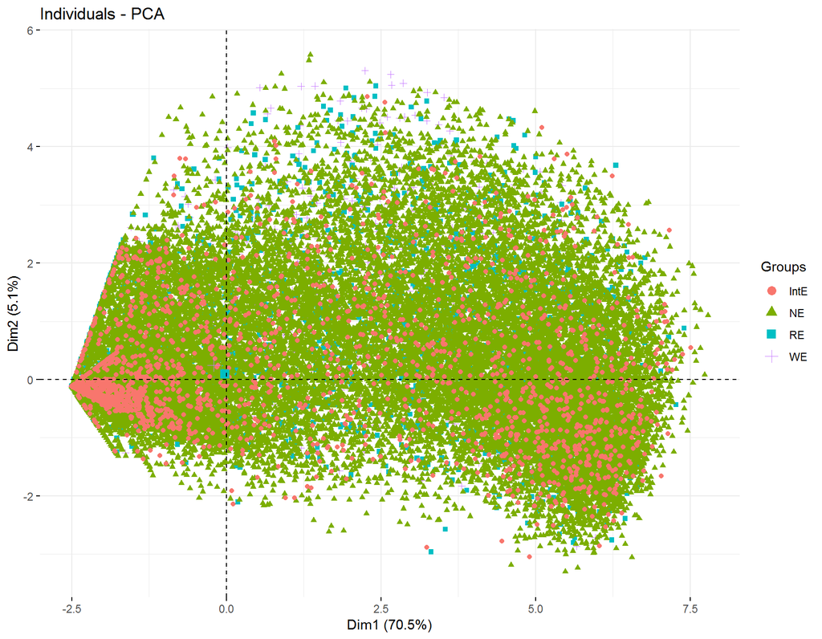

#### 3.10.2.2 choice 2: 3D scatter plot

`PC` should contain 3 values and length(`col`) should match with length(`PC`)

```r
analyse_integrated_individuals(start_end = start_end,
name = "OMICsdata", group = c("WE","RE","IntE"),
choice = 2, PC = c(1,2,3),
col = c("RED", "BLACK","GREEN"))
```

It seems the bimodal structure observed in case of individual assays also retained in integrated assays. This structure would be more clear if seen from the angle of density.

### 3.10.3 Density analysis of integrated data

The scatter plot of data points (here, rows/TSSs/individuals) may be highly disorganized. In such a situation, we may take the help of density functions to understand the overall structure of the dataset.

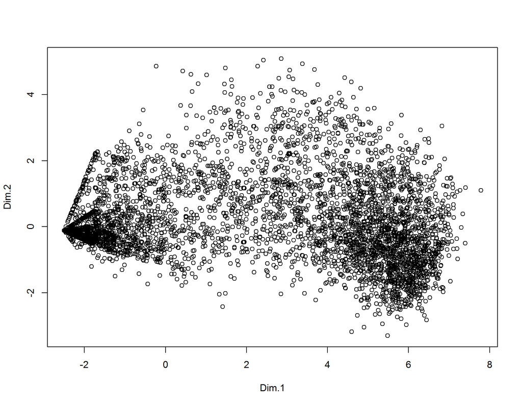

```r
#### extracting coordinates of TSSs randomly (rand = 1000)
## The description of "extract()" is given at the Cluster
## analysis section.
data <- extract(name = "OMICsdata", PC = c(1:4),
groups = c("WE","RE"), integrated = TRUE, rand = 10000)

## scatterplot on PC1 and 2
plot(data[,1:2])
```

#### 3.10.3.1 1D plot

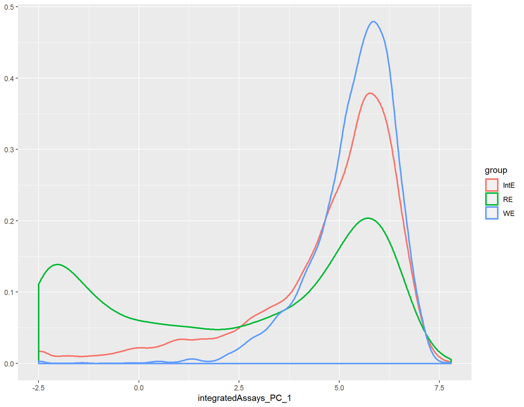

```r
densityplot <- plot_integrated_density(name = "OMICsdata", PC = 1,
groups = c("WE","RE","IntE"))
```

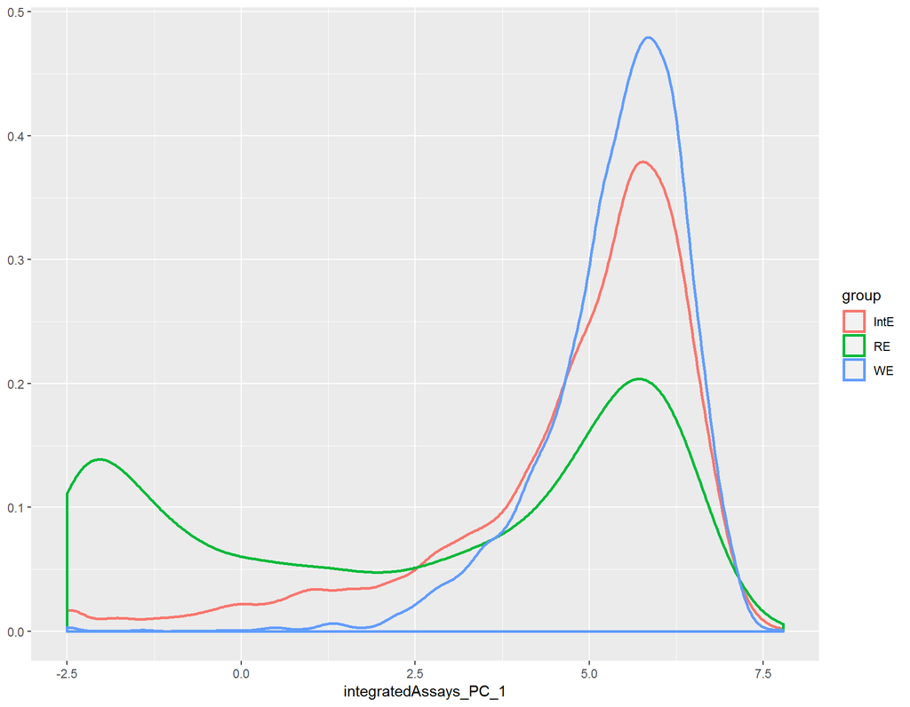

```r
class(densityplot)
# [1] "gg"     "ggplot"

# additional graphical functions (e.g. xlim, ylim, theme) may be
#added with densityplot (see section VIII. Density analysis)

densityplot
```

#### 3.10.3.2 3D plot

```r
plot_integrated_density_3D(name = "OMICsdata", PC1 = 1, PC2 = 2,
group = c("WE","RE"), gridsize = 100, static = FALSE)
```

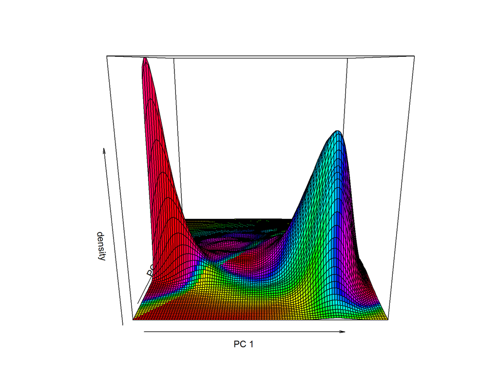

```r
plot_integrated_density_3D(name = "OMICsdata", PC1 = 1, PC2 = 2,
group = c("WE","RE"), gridsize = 100, static = TRUE)
```

```r
plot_integrated_density_3D(name = "OMICsdata", PC1 = 1, PC2 = 2,
group = "NE", gridsize = 100, static = TRUE)
```

The above analyses clearly indicate the presence of two broad groups according to combined epigenetic states of various expression groups. The obvious next job is to find out the TSSs in these groups.